# Semantic Web Technologies and Wikidata from R

Goran S. Milovanović

Wikimedia Deutschland, Data Scientist, DataKolektiv, Owner

Mike Page

DataKolektiv, Junior Data Scientist

25 јун 2019

### Notebook A: Accessing Wikidata and Wikipedia from R

**Feedback** should be send to `goran.milovanovic@datakolektiv.com`. These notebooks accompany the MilanoR talk 2019/06/25.

## 0. Setup

**Note.** The following chunks load packages and define the project directory tree.

```r
### --- setup
## - libraries
library(data.table)
library(dplyr)
library(stringr)
library(WikidataQueryServiceR)
library(WikipediR)
library(WikidataR)
library(httr)
library(jsonlite)
library(rvest)
### --- directories
dataDir <- 'data/'
analyticsDir <- 'analytics/'
funDir <- 'functions/'
```

## 1. Accessing Wikidata from R: the API and its R client library for Wikidata

### 1A. The {WikidataR} package

The {WikidataR} package wraps-up the [Wikidata MediaWiki API](https://www.wikidata.org/wiki/Wikidata:Data_access#MediaWiki_API) (see [API documentation](https://www.wikidata.org/w/api.php)) calls for you. If you are about to use the Wikidata directly API, use the modules that return JSON: `wbgetentities` and `wbsearchentities`.

**Example.** Retrieve `Q490` (it is: Milano) and study its structure.

```r
# - Retrieve the Wikidata item: Milano (Q490)
item <- get_item(id = 490)
class(item)
```

```
[1] "wikidata"
```

It is really a list:

```r
# - Retrieve the Wikidata item: Milano (Q490)
item_components <- sapply(item, names)
item_components
```

```
     [,1]
[1,] "type"
[2,] "id"
[3,] "labels"
[4,] "descriptions"
[5,] "aliases"
[6,] "claims"
[7,] "sitelinks"
```

`$type` is `item`:

```r
# - Retrieve the Wikidata item: Milano (Q490)
item[[1]]$type
```

```
[1] "item"
```

Labels is a list of `labels` in all available languages:

```r
labels <- lapply(item[[1]]$labels, function(x) {
  data.frame(language = unlist(x)[1],
             value = unlist(x)[2],
             stringsAsFactors = F)
})
labels <- rbindlist(labels)
head(labels, 10)
```

| language | value |
| --- | --- |
| tg | Милан |
| ay | Milano |
| pnb | میلان |
| mk | Милано |
| lt | Milanas |
| gd | Milano |
| ur | میلان |
| so | Milan |
| uk | Мілан |
| tt | Milan |

Item descriptions, in all available languages:

```r
descriptions <- lapply(item[[1]]$descriptions, function(x) {
  data.frame(language = unlist(x)[1],
             value = unlist(x)[2],
             stringsAsFactors = F)
})
descriptions <- rbindlist(descriptions)
head(descriptions, 10)
```

| language | value |
| --- | --- |
| la | Italiae municipium |
| en-gb | Italian comune |
| uz | Italiya kommunalari |
| fr | ville d'Italie |
| lt | komuna Italijoje |
| zh | 意大利市镇 |
| bar | ståd in Itálien |
| ceb | munisipyo sa Italya |
| fi | kaupunki Italiassa |
| vep | sur' lidn Italijan Lombardii-regionas |

Item aliases, in all available languages:

```r
aliases <- lapply(item[[1]]$aliases, function(x) {
  data.frame(language = unlist(x)[1],
             value = unlist(x)[2],
             stringsAsFactors = F)
})
aliases <- rbindlist(aliases)
head(aliases, 10)
```

| language | value |
| --- | --- |
| pa | ਮਿਲਾਨੋ, ਇਟਲੀ |
| ast | Milán (ciudá) |
| es | Milan |
| be | Горад Мілан |
| el | Μεδιολάνα |
| kn | kn |
| kk-cyrl | Милан қаласы |
| fr | Milano |
| hi | मिलान |
| en | en |

```r
sitelinks <- lapply(item[[1]]$claims, function(x) {
  data.frame(project = unlist(x)[1],
             value = unlist(x)[2],
             stringsAsFactors = F)
})
sitelinks <- rbindlist(sitelinks)
head(sitelinks, 10)
```

| project | value |
| --- | --- |
| value | P2924 |
| value | P373 |
| value | P1225 |
| value | value |
| value | P1667 |
| value | P625 |
| value | P910 |
| value | P3365 |
| value | P349 |
| value | P268 |

The main course: **claims**

```r
# - Retrieve the Wikidata item: Milano (Q490)
# list of all claims for Milano (Q490)
claims <- names(item[[1]]$claims)
head(claims, 20)
```

```
 [1] "P2924" "P373"  "P1225" "P1082" "P1667" "P625"  "P910"  "P3365" "P349"  "P268"  "P1791" "P242"
[13] "P1036" "P1334" "P227"  "P2046" "P6"    "P1792" "P1448" "P395"
```

What is `P2924`? Use `WikidataR::get_property()`:

```r
prop <- get_property(id = 'P2924')
prop[[1]]$labels$en$value
```

```
[1] "Great Russian Encyclopedia Online ID"
```

Describe Milano: of which Wikidata classes is `Milano (Q490)` an `instance of (P31)`?

```r
# - extract statements and ranks
itemP31Classes <- cbind(item[[1]]$claims$P31$mainsnak$datavalue$value,
                            item[[1]]$claims$P31$rank)
colnames(itemP31Classes) <- c('entity-type', 'numeric-id', 'id', 'rank')
itemP31Classes <- itemP31Classes %>%
  select(`entity-type`, id, rank)

# - fetch class labels
itemP31Classes_labels <- sapply(itemP31Classes$id, function(x) {
  i <- get_item(x)
  i[[1]]$labels$en$value
})
itemP31Classes$labels <- itemP31Classes_labels
# - extract statement qualifiers
itemP31Classes_qualifiers <- lapply(item[[1]]$claims$P31$qualifiers, function(x) {
  cl <- lapply(x, function(y) {
      if ('entity-type' %in% colnames(y$datavalue$value) & !is.null(y)) {
          data.frame(property = y$property,
                     value = y$datavalue$value$id,
                     stringsAsFactors = F)
      } else if ('time' %in% colnames(y$datavalue$value) & !is.null(y)) {
          data.frame(property = y$property,
                     value = y$datavalue$value$time,
                     stringsAsFactors = F)
        } else {
            data.frame(property = NA,
                       value = NA,
                       stringsAsFactors = F)
          }
  })
  rbindlist(cl, use.names = T, fill = T)
})
itemP31Classes_qualifiers <- Reduce(cbind, itemP31Classes_qualifiers)
length_prop_pairs <- length(colnames(itemP31Classes_qualifiers))/2
new_colnames <- unlist(lapply(1:length_prop_pairs, function(x) {
  paste0(c('property', 'value'), x)
  }))
colnames(itemP31Classes_qualifiers) <- new_colnames
# - cbind itemP31Classes and itemP31Classes_qualifiers
itemP31Classes <- cbind(itemP31Classes, itemP31Classes_qualifiers)
# - fetch all entity labels
searchEntities <- unique(c(itemP31Classes$id,
                         itemP31Classes$property1,
                         itemP31Classes$value1,
                         itemP31Classes$property2,
                         itemP31Classes$property3))
searchEntities <- searchEntities[!is.na(searchEntities)]
searchItems <- get_item(searchEntities[grepl("^Q", searchEntities)])
searchItems_labels <- sapply(searchItems, function(x) {
  x$labels$en$value
})
names(searchItems_labels) <- searchEntities[grepl("^Q", searchEntities)]
searchProperties <- get_property(searchEntities[grepl("^P", searchEntities)])
searchProperties_labels <- sapply(searchProperties, function(x) {
  x$labels$en$value
})
names(searchProperties) <- searchEntities[grepl("^P", searchEntities)]
# - replace entity IDs by labels in itemP31Classes
itemP31Classes$id <- sapply(itemP31Classes$id, function(x) {
  searchItems_labels[which(names(searchItems_labels) == x)]
})
itemP31Classes$value1 <- sapply(itemP31Classes$value1, function(x) {
  searchItems_labels[which(names(searchItems_labels) == x)]
})
itemP31Classes$property1 <- sapply(itemP31Classes$property1, function(x) {
  searchProperties_labels[which(names(searchProperties) == x)]
})
itemP31Classes$property2 <- sapply(itemP31Classes$property2, function(x) {
  searchProperties_labels[which(names(searchProperties) == x)]
})
itemP31Classes$property3 <- sapply(itemP31Classes$property3, function(x) {
  searchProperties_labels[which(names(searchProperties) == x)]
})
# - format output
# - extract year only from time
itemP31Classes$value2 <- unlist(str_extract_all(itemP31Classes$value2,
                                         "\\d\\d\\d\\d"))
itemP31Classes$value3 <- unlist(str_extract_all(itemP31Classes$value3,
                                         "\\d\\d\\d\\d"))
describeMilano <- paste0("Milan is a ",
                         itemP31Classes$labels, " ",
                         itemP31Classes$property1, " ",
                         itemP31Classes$value1, " ",
                         itemP31Classes$value2, " - ", itemP31Classes$value3)
describeMilano <- gsub("character.*|NA.*", "", describeMilano)
describeMilano <- data.frame(description = describeMilano)
describeMilano
```

| description |
| --- |
| Milan is a chef-lieu of Lombardy 1970 - |
| Milan is a chef-lieu of province of Milan 1860 - 2015 |
| Milan is a comune of Italy |
| Milan is a city |
| Milan is a chef-lieu of Metropolitan City of Milan 2015 - |

The `WikidataR::find_item()` function: search Wikidata (and good luck with Word-Sense Disambiguation)

```r
Milano <- find_item('Milan')
Milano
```

```
    Wikidata item search

Number of results:   10

Results:
1    Milan (Q490) - second-largest city in Italy
2    Milan (Q1076681) - male given name
3    family medicine (Q3505712) - medical specialty
4    Milan (Q1645063) - village in Ohio, USA
5    MILAN (Q1463375) - 1970s anti-tank missile by Aerospatiale and MBB (later Euromissile)
6    Milan (Q965421) - city in Missouri, USA
7    Milan (Q1856043) - city in Gibson County, Tennessee
8    Milan (Q1924803) - city in Minnesota, United States
9    Milan (Q1022976) - village in Illinois, USA
10   Milan (Q1934225) - city in Michigan, United States
```

What?! Where is my favorite football club?

```r
MilanoAC <- find_item('AC Milan')
MilanoAC
```

```
    Wikidata item search

Number of results:   10

Results:
1    Associazione Calcio Milan (Q1543) - italian association football club based in the city of Milan founded in 1899
2    A.C. Milan (Q55602896) - women's section of Italian association football club based in Milan
3    AC Milan fans (Q3991244) - organization
4    AC Milanese DG (Q14626481)
5    2005 UEFA Champions League Final (Q757107) - association football match
6    A.C. Milan Primavera (Q3299830)
7    A.C. Milan in European football (Q2305544) - Wikimedia list article
8    HC Devils Milano (Q1059896) - Ice hockey team in Milan, Italy
9    2009–10 A.C. Milan season (Q263392) - sports season
10   2010–11 A.C. Milan season (Q919754) - sports season
```

### 1B. The Wikidata MediaWiki API

You really need to browse the documentation for this carefully. Focus on the following modules: `wbgetentities` and `wbsearchentities`.

*Example.* `wbgetentities`

```r
# - Wikidata MediaWiki API prefix
APIprefix <- 'https://www.wikidata.org/w/api.php?action=wbgetentities&'
# - Random Wikidata item
ids <- paste0("Q", round(runif(20, 1, 1000)))
ids <- paste0(ids, collapse = "|")
# - Compose query
query <- paste0(APIprefix,
                    'ids=', ids, '&',
                    'props=labels&languages=en&sitefilter=wikidatawiki&format=json')
# - contact the API
result <- GET(url = URLencode(query))
# - raw to char
result <- rawToChar(result$content)
# - to JSON:
result <- fromJSON(result)
# - parse JSON:
itemLabels <- unlist(lapply(result$entities, function(x) {
  x$labels$en$value
  }))
itemLabels <- data.frame(entity_id = names(itemLabels),
                         label = itemLabels,
                         stringsAsFactors = F)
itemLabels
```

|  | entity_id | label |
| --- | --- | --- |
| Q443 | Q443 | Ich bin ein Berliner |
| Q83 | Q83 | MediaWiki |
| Q447 | Q447 | Encyclopédie |
| Q459 | Q459 | Plovdiv |
| Q260 | Q260 | Jean-François Champollion |
| Q371 | Q371 | !!! |
| Q424 | Q424 | Cambodia |
| Q217 | Q217 | Moldova |
| Q20 | Q20 | Norway |
| Q547 | Q547 | Witterschlick |

[output cut: 10 more lines]

*Example.* `wbsearchentities`

```r
# - Wikidata MediaWiki API prefix
APIprefix <- 'https://www.wikidata.org/w/api.php?action=wbsearchentities&'
# - search query
searchQuery <- "AC Milan"
# - Compose query
query <- paste0(APIprefix,
                    'search=', searchQuery, '&',
                    'language=en&strictlanguage=true&format=json')
# - contact the API
result <- GET(url = URLencode(query))
# - raw to char
result <- rawToChar(result$content)
# - to JSON:
searchResult <- fromJSON(result, simplifyDataFrame = T)
# - fetch labels and descriptions
searchResult <- get_item(searchResult$search$id)
# - labels and descriptions
descriptions <- sapply(searchResult, function(x) {
  paste0(x$labels$en$value, ": ", x$descriptions$en$value)
})
descriptions
```

```
[1] "Associazione Calcio Milan: italian association football club based in the city of Milan founded in 1899"
[2] "A.C. Milan: women's section of Italian association football club based in Milan"
[3] "AC Milan fans: organization"
[4] "AC Milanese DG: "
[5] "2005 UEFA Champions League Final: association football match"
[6] "A.C. Milan Primavera: "
[7] "A.C. Milan in European football: Wikimedia list article"
```

## 2. Accessing Wikipedia from R: the API and its R client library for Wikipedia

### 2A. The {WikipediR} package

How do I get to collect the content of the English Wikipedia page for a particular Wikidata item? First we need the item’s `sitelink` to English Wikipedia (it is the title of the page in the desired Wikipedia):

```r
# - Retrieve the Wikidata item: Milano (Q490)
item <- get_item(id = 'Q1543')
sitelink <- item[[1]]$sitelinks$enwiki$title
sitelink
```

```
[1] "A.C. Milan"
```

```r
ACMilan_content <- page_content(language = "en",
                                project = "Wikipedia",
                                page_name = sitelink,
                                as_wikitext = FALSE)
str(ACMilan_content)
```

```
List of 1
 $ parse:List of 4
  ..$ title : chr "A.C. Milan"
  ..$ pageid: int 18940588
  ..$ revid : int 903219804
  ..$ text  :List of 1
  .. ..$ *: chr "<div class=\"mw-parser-output\"><div role=\"note\" class=\"hatnote navigation-not-searchable\">This article is "| __truncated__
 - attr(*, "class")= chr "pcontent"
```

*Explanation:* `$title` is, obviously, the page title, `$pageid` is the Wikipedia page id (can also be used in `page_content` to search for a page id), `revid` is the *revision id* (each time a Wikipedia page gets edited this is updated), and `$text` is the HTML of the page (note: it is HTML because we have used `as_wikitext = FALSE`, otherwise it would be wikitext - the MediaWiki mark-up).

```r
substr(ACMilan_content$parse$text[[1]], 1, 2000)
```

```
[1] "<div class=\"mw-parser-output\"><div role=\"note\" class=\"hatnote navigation-not-searchable\">This article is about the men's football club from Milan, Italy. For the women's team, see <a href=\"/wiki/A.C._Milan_Women\" title=\"A.C. Milan Women\">A.C. Milan Women</a>. For other sports teams ca…
```

Followint HTML removal with `{rvest}` `html_text()`:

```r
substr(html_text(read_html(ACMilan_content$parse$text[[1]])), 1, 2000)
```

```
[1] "This article is about the men's football club from Milan, Italy. For the women's team, see A.C. Milan Women. For other sports teams called Milan, see Milan (disambiguation) § Sports.\n\n\n\n\nMilanFull nameAssociazione Calcio Milan S.p.A.[1]Nickname(s)I Rossoneri (The Red and Blacks)Il Diavolo …
```

Because we are here mostly interested in structural properties of Wikipedia, the next {WikipediR} function that we review is `page_backlinks`. It retrieves the Wikipedia pages that have links towards the page under question. *Note:* the `namespaces` argument refers to the [Wikipedia namespaces](https://en.wikipedia.org/wiki/Wikipedia:Namespace), and `namespace = 0` is the content namespace (precisely: Main/Article). Wikidata also has its own [namespace](https://www.wikidata.org/wiki/Help:Namespaces).

```r
ACMilan_backlinks <-
  page_backlinks(language = "en",
                 project = "Wikipedia",
                 page = sitelink,
                 namespaces = 0)
# - structure
backlinks1 <- sapply(ACMilan_backlinks$query$backlinks, function(x) {
  x$title
})
backlinks1
```

```
 [1] "Audi"                           "Auto racing"                    "Arsenal F.C."
 [4] "AFC Ajax"                       "A.S. Roma"                      "ACF Fiorentina"
 [7] "AC Milan"                       "Bobby Charlton"                 "A.C. ChievoVerona"
[10] "Chelsea F.C."                   "Dino Zoff"                      "Diego Maradona"
[13] "David Beckham"                  "Dundee"                         "Franco Baresi"
[16] "Gheorghe Hagi"                  "Hellas Verona F.C."             "Inter Milan"
[19] "Serie A"                        "Juventus F.C."                  "Liverpool F.C."
[22] "Manchester United F.C."         "Pelé"                           "Roberto Baggio"
[25] "Real Madrid CF"                 "Silvio Berlusconi"              "S.S. Lazio"
[28] "Valencia CF"                    "2000s (decade)"                 "1963"
[31] "1995"                           "1899"                           "1958"
[34] "Milan"                          "Yankee Stadium (1923)"          "Aston Villa F.C."
[37] "1948 Summer Olympics"           "UEFA Champions League"          "West Ham United F.C."
[40] "Feyenoord"                      "Mitropa Cup"                    "Fabien Barthez"
[43] "Marco van Basten"               "Cádiz"                          "Ruud Gullit"
[46] "Hillsborough disaster"          "Parma Calcio 1913"              "Ronaldo (Brazilian footballer)"
[49] "FC Barcelona"                   "Tottenham Hotspur F.C."
```

*Note.* The `page_backlinks` will return at maximum 50 backlinks (the default value of the `limit` parameter, see [WikipediR manual](https://cran.r-project.org/web/packages/WikipediR/WikipediR.pdf)). Let’s collect the backlinks of the AC Milan’s backlinks:

```r
ACMilan_backlinks2 <- lapply(backlinks1, function(x) {
  page_backlinks(language = "en",
                 project = "Wikipedia",
                 page = x,
                 namespaces = 0)
})
# - structure
backlinks2 <- lapply(ACMilan_backlinks2, function(x) {
  sapply(x$query$backlinks, function(y) {
  y$title
  })
})
names(backlinks2) <- backlinks1
```

What does the connectivity pattern looks like?

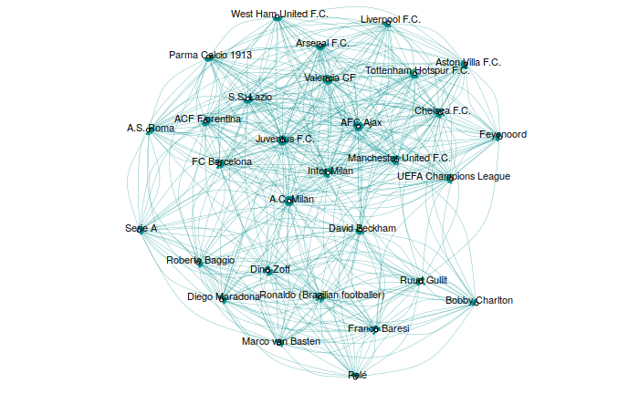

```r
backlinks1 <- data.frame(outgoing = backlinks1,
                         incoming = "A.C. Milan",
                         stringsAsFactors = F)
backlinks2 <- stack(backlinks2)
backlinks2 <- data.frame(outgoing = backlinks2$values,
                         incoming = backlinks2$ind,
                         stringsAsFactors = F)
pattern <- rbind(backlinks1, backlinks2)
# - fix "AC Milan" to "A.C. Milan"
pattern$outgoing <- gsub("AC Milan", "A.C. Milan", pattern$outgoing, fixed = T)
pattern$incoming <- gsub("AC Milan", "A.C. Milan", pattern$incoming, fixed = T)
# - keep only nodes that receive any links
w <- which(pattern$outgoing %in% pattern$incoming)
pattern <- pattern[w, ]
# - filter for the top 30 hubs to keep the network readable
mfreq_nodes <- names(sort(table(pattern$incoming), decreasing = T)[1:30])
pattern <- filter(pattern,
                  incoming %in% mfreq_nodes & outgoing %in% mfreq_nodes)
pattern <- pattern[pattern$outgoing != pattern$incoming, ]
# - visualize w. {igraph}
library(igraph)
ACMilan_net <- graph.data.frame(pattern,
                                directed = T)
# - plot w. {igraph}
par(mai = c(rep(0,4)))
plot(ACMilan_net,
     edge.width = .25,
     edge.color = "darkcyan",
     edge.arrow.size = 0.15,
     vertex.size = 2,
     vertex.color = "white",
     vertex.label.color = "black",
     vertex.label.font = 1,
     vertex.label.family = "sans",
     vertex.label.cex = .68,
     vertex.label.dist = .25,
     vertex.label.dist = .45,
     edge.curved = 0.5,
     margin = c(rep(0,4)))
```

### 2B. The Wikipedia MediaWiki API

The API documentation is [here](https://www.mediawiki.org/wiki/API:Main_page); the API:Query (`action=query`) modules are especially interesting.

```r
# - English Wikipedia MediaWiki API prefix
APIprefix <- 'https://en.wikipedia.org/w/api.php?'
# - search query
titles <- "A.C. Milan"
# - fix search query: replace all '\\s' (regex: space) by '_'
titles <- gsub("\\s", "_", titles)
# - Compose query
query <- paste0(APIprefix,
                    'action=query&prop=extracts&titles=Stack%20Overflow&redirects=true&format=json&titles=',
                    titles)
# - contact the API
result <- GET(url = URLencode(query))
# - raw to char
result <- rawToChar(result$content)
# - to JSON:
searchResult <- fromJSON(result, simplifyDataFrame = T)
# - extract page content from JSON and clean-up HTML from {rvest}
pageContent <- searchResult$query$pages$`18940588`$extract
substr(html_text(read_html(pageContent)), 1, 2000)
```

```
[1] "\n\n\n\nAssociazione Calcio Milan (Italian pronunciation: [assotʃatˈtsjoːne ˈkaltʃo ˈmiːlan]), commonly referred to as A.C. Milan or simply Milan, is a professional football club in Milan, Italy, founded in 1899. The club has spent its entire history, with the exception of the 1980–81 and 1982–…
```

*Note.* Remember how the constraint of the `page_backlinks` function in `{WikipediR}` was that it will return at maximum 50 backlinks from a particular page? That is actually a constraint of the MediaWiki API, and it can be bypassed by **query continuation**.

```r
# - collect all backlinks from A. C. Milan
# - English Wikipedia MediaWiki API prefix
APIprefix <- 'https://en.wikipedia.org/w/api.php?'
# - search query
titles <- "A.C. Milan"
# - fix search query: replace all '\\s' (regex: space) by '_'
titles <- gsub("\\s", "_", titles)
# - Compose query
query <- paste0(APIprefix,
                    'action=query&list=backlinks&format=json&bltitle=',
                    titles)
# - contact the API
result <- GET(url = URLencode(query))
# - raw to char
result <- rawToChar(result$content)
# - to JSON:
backlinks <- fromJSON(result, simplifyDataFrame = T)
backlinks$query$backlinks
```

|  | pageid | ns | title | redirect |
| --- | --- | --- | --- | --- |
| 1 | 848 | 0 | Audi | NA |
| 2 | 1022 | 0 | Auto racing | NA |
| 3 | 2174 | 0 | Arsenal F.C. | NA |
| 4 | 2273 | 0 | AFC Ajax | NA |
| 5 | 2358 | 0 | A.S. Roma | NA |
| 6 | 3165 | 0 | ACF Fiorentina | NA |
| 7 | 3166 | 0 | AC Milan |  |
| 8 | 4224 | 0 | Bobby Charlton | NA |
| 9 | 6903 | 0 | A.C. ChievoVerona | NA |
| 10 | 7473 | 0 | Chelsea F.C. | NA |

Note the presence of the `continue` element:

```r
str(backlinks)
```

```
List of 3
 $ batchcomplete: chr ""
 $ continue     :List of 2
  ..$ blcontinue: chr "0|8138"
  ..$ continue  : chr "-||"
 $ query        :List of 1
  ..$ backlinks:'data.frame':   10 obs. of  4 variables:
  .. ..$ pageid  : int [1:10] 848 1022 2174 2273 2358 3165 3166 4224 6903 7473
  .. ..$ ns      : int [1:10] 0 0 0 0 0 0 0 0 0 0
  .. ..$ title   : chr [1:10] "Audi" "Auto racing" "Arsenal F.C." "AFC Ajax" ...
  .. ..$ redirect: chr [1:10] NA NA NA NA ...
```

In order to obtain the next set of results, we need to pass the value of the `continue` parameter to our next API call:

```r
# - continue backlinks from A. C. Milan
# - value of the continue paramater from the previous API call:
continue <- backlinks$continue$continue
blcontinue <- backlinks$continue$blcontinue
# - English Wikipedia MediaWiki API prefix
APIprefix <- 'https://en.wikipedia.org/w/api.php?'
# - search query
titles <- "A.C. Milan"
# - fix search query: replace all '\\s' (regex: space) by '_'
titles <- gsub("\\s", "_", titles)
# - Compose query
query <- paste0(APIprefix,
                    'action=query&list=backlinks&format=json&bltitle=',
                    titles, '&continue=', continue, '&blcontinue=', blcontinue)
# - contact the API
result <- GET(url = URLencode(query))
# - raw to char
result <- rawToChar(result$content)
# - to JSON:
backlinks2 <- fromJSON(result, simplifyDataFrame = T)
backlinks2$query$backlinks
```

|  | pageid | ns | title |
| --- | --- | --- | --- |
| 1 | 8138 | 0 | Dino Zoff |
| 2 | 8485 | 0 | Diego Maradona |
| 3 | 8618 | 0 | David Beckham |
| 4 | 8828 | 0 | Dundee |
| 5 | 10855 | 0 | Franco Baresi |
| 6 | 12276 | 0 | Gheorghe Hagi |
| 7 | 14035 | 0 | Hellas Verona F.C. |
| 8 | 15116 | 0 | Inter Milan |
| 9 | 15496 | 0 | Serie A |
| 10 | 16415 | 0 | Juventus F.C. |

Let’s collect *all* backlinks from the `A. C. Milan` page:

```r
# - store results
backlinks <- list()
# - English Wikipedia MediaWiki API prefix
APIprefix <- 'https://en.wikipedia.org/w/api.php?'
# - search query
titles <- "A.C. Milan"
# - compose initial query
query <- paste0(APIprefix,
                'action=query&list=backlinks&format=json&bltitle=',
                titles)
# - count
counter = 1
repeat {
  # - contact the API
  result <- GET(url = URLencode(query))
  # - parse result
  # - raw to char
  result <- rawToChar(result$content)
  # - to JSON:
  result <- fromJSON(result, simplifyDataFrame = T)
  # - content:
  backlinks[[counter]] <- result$query$backlinks
  # - check if there are more results
  if (!is.null(result$continue$continue)) {
    # - pick up continuation parameters
    continue <- result$continue$continue
    blcontinue <- result$continue$blcontinue
    # - increase counter
    counter <- counter + 1
    # - Compose continuation query
    query <- paste0(APIprefix,
                    'action=query&list=backlinks&format=json&bltitle=',
                    titles, '&continue=', continue, '&blcontinue=', blcontinue)
  } else {
    break
  }
}
backlinks <- rbindlist(backlinks,
                       use.names = T,
                       fill = T)
head(backlinks, 100)
```

| pageid | ns | title | redirect |
| --- | --- | --- | --- |
| 848 | 0 | Audi | NA |
| 1022 | 0 | Auto racing | NA |
| 2174 | 0 | Arsenal F.C. | NA |
| 2273 | 0 | AFC Ajax | NA |
| 2358 | 0 | A.S. Roma | NA |
| 3165 | 0 | ACF Fiorentina | NA |
| 3166 | 0 | AC Milan |  |
| 4224 | 0 | Bobby Charlton | NA |
| 6903 | 0 | A.C. ChievoVerona | NA |
| 7473 | 0 | Chelsea F.C. | NA |

[output cut: 90 more lines]

*Note.* Also, see Python example w. the `requests` module [here](https://www.mediawiki.org/wiki/API:Query#Continuing_queries).

Indeed, the English Wikipedia page for `A.C. Milan` has **many more backlinks** that we were able to collect initially:

```r
dim(backlinks)[1]
```

```
[1] 5232
```

Here’s a function to collect all of the page’s backlinks via the MediaWiki API (not production-ready; mind the packages that you might need):

```r
collect_backlinks <- function(API_prefix, titles) {

  # - result
  backlinks <- list()
  # - compose initial query
  query <- paste0(APIprefix,
                  'action=query&list=backlinks&format=json&bltitle=',
                  titles)
  # - count
  counter = 1

  repeat {
    # - contact the API
    repeat {
     result <- tryCatch({
       GET(url = URLencode(query))},
       error = function(condition) {
         FALSE
       })
     if (!(class(result) == 'logical')) {
       break
     }
    }

    # - parse result
    # - raw to char
    result <- rawToChar(result$content)
    # - to JSON:
    result <- fromJSON(result, simplifyDataFrame = T)
    # - content:
    backlinks[[counter]] <- result$query$backlinks
    # - check if there are more results
    if (!is.null(result$continue$continue)) {
      # - pick up continuation parameters
      continue <- result$continue$continue
      blcontinue <- result$continue$blcontinue
      # - increase counter
      counter <- counter + 1
      # - Compose continuation query
      query <- paste0(APIprefix,
                      'action=query&list=backlinks&format=json&bltitle=',
                      titles, '&continue=', continue, '&blcontinue=', blcontinue)
    } else {
      break
    }
  }
  backlinks <- rbindlist(backlinks,
                         use.names = T,
                         fill = T)
  return(backlinks)
}
# - collect A.C. Milan backlinks:
# - English Wikipedia MediaWiki API prefix
APIprefix <- 'https://en.wikipedia.org/w/api.php?'
# - search query
titles <- "A.C. Milan"
backlinks <- collect_backlinks(API_prefix = APIprefix,
                               titles = titles)
```

The result, again:

```r
head(backlinks, 100)
```

| pageid | ns | title | redirect |
| --- | --- | --- | --- |
| 848 | 0 | Audi | NA |
| 1022 | 0 | Auto racing | NA |
| 2174 | 0 | Arsenal F.C. | NA |
| 2273 | 0 | AFC Ajax | NA |
| 2358 | 0 | A.S. Roma | NA |
| 3165 | 0 | ACF Fiorentina | NA |
| 3166 | 0 | AC Milan |  |
| 4224 | 0 | Bobby Charlton | NA |
| 6903 | 0 | A.C. ChievoVerona | NA |
| 7473 | 0 | Chelsea F.C. | NA |

[output cut: 90 more lines]

## 3. Accessing Wikidata from R: SPARQL

### 3A. SPARQL via WDQS (Wikidata Query Service)

```r
# - WDQS endPoint:
endPointURL <- "https://query.wikidata.org/bigdata/namespace/wdq/sparql?format=json&query="
# - query:
query <- 'SELECT ?item ?itemLabel WHERE {
  ?item wdt:P31 wd:Q9143 .
   SERVICE wikibase:label { bd:serviceParam wikibase:language "en". }
}'
res <- GET(url = paste0(endPointURL, URLencode(query)))
res$status_code
```

```
[1] 200
```

```r
# - decode:
res <- rawToChar(res$content)
substr(res, 1, 2000)
```

```
[1] "{\n  \"head\" : {\n    \"vars\" : [ \"item\", \"itemLabel\" ]\n  },\n  \"results\" : {\n    \"bindings\" : [ {\n      \"item\" : {\n        \"type\" : \"uri\",\n        \"value\" : \"http://www.wikidata.org/entity/Q59\"\n      },\n      \"itemLabel\" : {\n        \"xml:lang\" : \"en\",\n       …
```

```r
# - from JSON:
res <- fromJSON(res)
class(res)
```

```
[1] "list"
```

```r
items <- res$results$bindings$item
labels <- res$results$bindings$itemLabel
```

```r
# - inspect result:
head(items)
```

|  | type | value |
| --- | --- | --- |
| 1 | uri | http://www.wikidata.org/entity/Q59 |
| 2 | uri | http://www.wikidata.org/entity/Q2005 |
| 3 | uri | http://www.wikidata.org/entity/Q2366 |
| 4 | uri | http://www.wikidata.org/entity/Q2370 |
| 5 | uri | http://www.wikidata.org/entity/Q2378 |
| 6 | uri | http://www.wikidata.org/entity/Q2407 |

```r
# - inspect result:
head(labels)
```

|  | xml:lang | type | value |
| --- | --- | --- | --- |
| 1 | en | literal | PHP |
| 2 | en | literal | JavaScript |
| 3 | en | literal | AngelScript |
| 4 | en | literal | C# |
| 5 | en | literal | Visual Basic |
| 6 | en | literal | C++ |

```r
# - data.frame:
programmingLanguages <- data.frame(items = gsub("http://www.wikidata.org/entity/", "", items$value),
                                   labels = labels$value,
                                   stringsAsFactors = F)
head(programmingLanguages, 10)
```

|  | items | labels |
| --- | --- | --- |
| 1 | Q59 | PHP |
| 2 | Q2005 | JavaScript |
| 3 | Q2366 | AngelScript |
| 4 | Q2370 | C# |
| 5 | Q2378 | Visual Basic |
| 6 | Q2407 | C++ |
| 7 | Q5288 | Tool Command Language |
| 8 | Q13743 | Visual Basic Script |
| 9 | Q15777 | C |
| 10 | Q16340 | XPath |

Goran S. Milovanović & Mike Page

DataKolektiv, 2019.

contact: datakolektiv@datakolektiv.com